# ETF Trend Prediction — Data Preparation Report

European ETFs: IEUR, FEZ, EUFN

## 1. Overview

This report documents the data preparation pipeline for our ETF trend prediction project, which adapts the methodology of Sagaceta-Mejía et al. (2024) to three European ETFs:

| Ticker | Fund | Focus |
| --- | --- | --- |
| **IEUR** | iShares Core MSCI Europe ETF | Broad European market |
| **FEZ** | SPDR EURO STOXX 50 ETF | Eurozone large-cap |
| **EUFN** | iShares MSCI Europe Financials ETF | European financials |
| **IVV** | iShares Core S&P 500 ETF | Developed benchmark |

Data spans **2010-01-01 → 2026-04-30**, extending the paper’s original pre-pandemic window to include recent market conditions including the COVID-19 period and subsequent recovery.

## 2. Setup

```python
import sys
from pathlib import Path

PROJECT_ROOT = Path.cwd().parent
sys.path.insert(0, str(PROJECT_ROOT / "src"))

import logging
logging.basicConfig(level=logging.WARNING)

import matplotlib.pyplot as plt
from etf_predictor.data.loader import YahooFinanceLoader
from etf_predictor.data.pipeline import DataPipeline
from etf_predictor.data.visualization import EDAVisualizer

TICKERS = ["IEUR", "FEZ", "EUFN"]
START   = "2010-01-01"
END     = "2026-05-01"
```

## 3. Raw Data

```python
loader = YahooFinanceLoader(tickers=TICKERS, start=START, end=END)
raw_data = loader.load()

for ticker, df in raw_data.items():
    print(f"{ticker}: {len(df)} rows, {df.index[0].date()} → {df.index[-1].date()}")
```

```
IEUR: 2989 rows, 2014-06-12 → 2026-04-30
FEZ: 4106 rows, 2010-01-04 → 2026-04-30
EUFN: 4085 rows, 2010-02-03 → 2026-04-30
IVV: 4106 rows, 2010-01-04 → 2026-04-30
```

Note: IEUR only has data from 2014-06-12 — this is a Yahoo Finance data availability limitation, not a pipeline issue.

### 3.1 Open Price Summary Statistics

```python
import pandas as pd

summary = pd.concat(
    {t: raw_data[t]["Open"].describe() for t in TICKERS},
    axis=1
).round(2)
summary
```

|  | IEUR | FEZ | EUFN |
| --- | --- | --- | --- |
| count | 2989.00 | 4106.00 | 4085.00 |
| mean | 50.46 | 40.46 | 21.04 |
| std | 8.08 | 8.10 | 4.65 |
| min | 31.62 | 25.02 | 10.79 |
| 25% | 44.70 | 35.05 | 18.12 |
| 50% | 48.70 | 39.06 | 20.30 |
| 75% | 55.12 | 43.53 | 23.22 |
| max | 76.77 | 69.37 | 38.89 |

### 3.2 Normalised Open Price Over Time

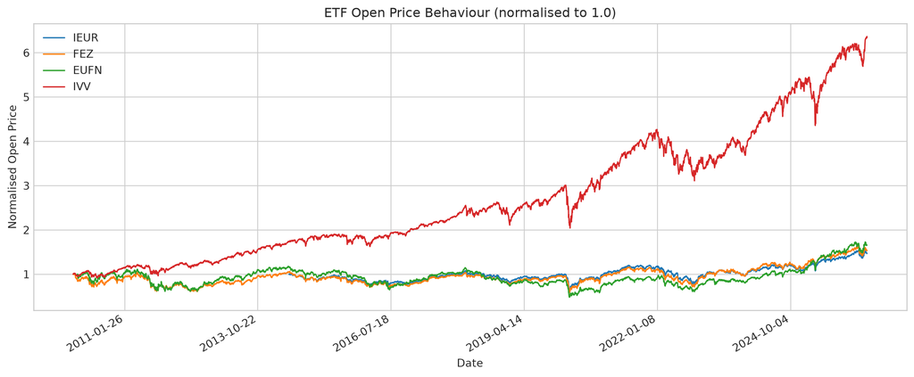

```python
viz = EDAVisualizer()
fig = viz.plot_open_prices(raw_data, normalize=True)
plt.show()
```

*IVV (S&P 500) is included as a developed-market benchmark. The US index shows a stronger upward trend over the full period, with European ETFs exhibiting higher volatility around the 2020 COVID-19 shock and the 2022 rate-hiking cycle.*

### 3.3 Sector Exposure

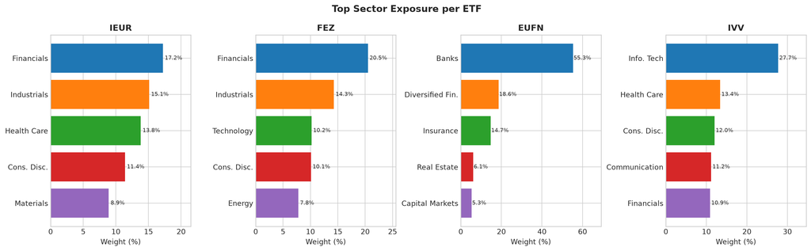

```python
fig = viz.plot_sector_exposure()
plt.show()
```

*EUFN is almost entirely financials; FEZ is Eurozone large-cap heavy in financials and industrials; IEUR is broadly diversified. This sectoral heterogeneity makes direct indicator comparison between the three funds theoretically interesting.*

## 4. Pipeline

```python
pipeline = DataPipeline(
    tickers=TICKERS,
    start=START,
    end=END,
    include_benchmark=True,
)
datasets = pipeline.run(save=True)
pipeline.summary(datasets)
```

| ticker | rows | features | up_pct | down_pct |
| --- | --- | --- | --- | --- |
| IEUR | 2735 | 252 | 53.35 | 46.65 |
| FEZ | 3852 | 252 | 52.47 | 47.53 |
| EUFN | 3831 | 251 | 51.66 | 48.34 |
| IVV | 3852 | 252 | 55.74 | 44.26 |

### 4.1 Technical Indicators

The Pandas TA library (v0.4.x) expands the 6 base OHLCV features to **~250 daily features** across 10 categories. Sparse columns with more than 95% NaN values (e.g. ZIGZAG) are automatically removed before cleaning.

**Look-ahead check.** Every indicator is tested for causality by recomputing it on data truncated at day t and checking that none of its values up to day t change. With default settings, five pandas-ta indicators fail this test and are dropped: DPO (centred, shifts the close backwards), the Ichimoku chikou span `ICS_26` (the close 26 days in the future), the `TOS_STDEVALL` regression bands (fitted on the whole sample), `VHM` (normalised with future data) and `ZIGZAG` (pivots confirmed only by later prices). Ichimoku’s forward span projections, dated after the last trading day, are also discarded. The check runs in the unit tests, so a library upgrade that introduces a new look-ahead indicator fails the build.

The raw `Adj Close` column is excluded from the features as well: Yahoo back-adjusts it with dividends paid after each day, so its historical values are revised whenever a new dividend arrives. Indicators are computed on the unadjusted `Close`.

| Category | Examples |
| --- | --- |
| Candles | Candlestick patterns |
| Cycles | Even Better SineWave (EBSW) |
| Momentum | RSI, Stochastic RSI, Williams %R, KDJ |
| Overlap | SMA, EMA, Bollinger Bands |
| Performance | Annualised returns |
| Statistics | Z-Score, variance |
| Trend | CTI, TTM Trend, ADX |
| Utility | Helper features |
| Volatility | ATR, Bollinger Band % |
| Volume | AOBV, PVR, OBV |

### 4.2 Classification Target Γ(t)

Following the paper (Section 2.4):

$$\Gamma(t) = \begin{cases} +1 & \text{if } \text{Open}(t) - \text{Open}(t-1) > 0 \\ -1 & \text{otherwise} \end{cases}$$

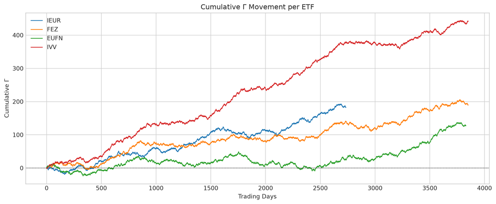

```python
fig = viz.plot_cumulative_gamma(datasets)
plt.show()
```

### 4.3 Class Balance

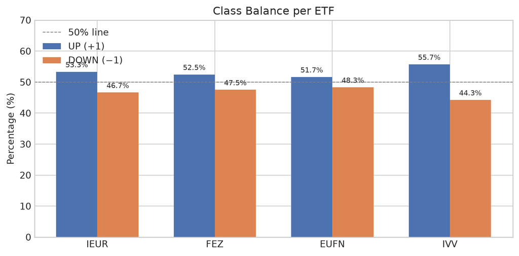

```python
fig = viz.plot_class_balance(datasets)
plt.show()
```

*All three ETFs show a slight UP bias (~51–53%), consistent across the full 2010–2026 period including both bull and bear market phases.*

## 5. Preprocessing

### 5.1 Normalisation

Each feature is min-max scaled to **[0, 1]**, but causally: the min and max are those observed **up to that day**, not over the whole sample:

$$\hat{x}_t = \frac{x_t - \min_{s \le t} x_s}{\max_{s \le t} x_s - \min_{s \le t} x_s}$$

The paper scales with full-sample statistics, which leaks the future range of every feature into earlier rows once the data is split into walk-forward folds. Expanding-window scaling avoids this while keeping a single processed dataset that every fold can share.

### 5.2 Cleaning

Two-stage cleaning is applied:

1. **Sparse column removal** — columns with >95% NaN (e.g. ZIGZAG indicator) are dropped entirely before row-level cleaning.
2. **Forward-fill** — remaining NaN values from indicator warm-up periods are forward-filled, then any residual NaN rows are dropped.

```python
for ticker, df in datasets.items():
    n_nan = df.isna().sum().sum()
    print(f"{ticker}: {len(df)} rows remaining, {n_nan} NaN values")
```

```
IEUR: 2735 rows remaining, 0 NaN values
FEZ: 3852 rows remaining, 0 NaN values
EUFN: 3831 rows remaining, 0 NaN values
IVV: 3852 rows remaining, 0 NaN values
```

## 6. Feature Correlation (Selected Indicators)

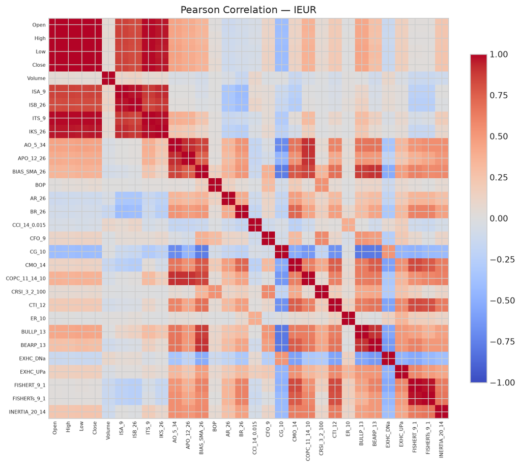

```python
fig = viz.plot_correlation_heatmap(
    datasets["IEUR"],
    ticker="IEUR",
)
plt.show()
```

## 7. Handoff Contract

The modeling team receives:

```python
# Verify handoff contract
for ticker, df in datasets.items():
    assert df.isna().sum().sum() == 0, f"{ticker} has NaNs!"
    assert "Gamma" in df.columns
    assert df["Gamma"].isin([1, -1]).all()
    feature_cols = [c for c in df.columns if c != "Gamma"]
    assert df[feature_cols].min().min() >= -0.01
    print(f"{ticker} ✓  shape={df.shape}")
```

```
IEUR ✓  shape=(2735, 253)
FEZ ✓  shape=(3852, 253)
EUFN ✓  shape=(3831, 252)
IVV ✓  shape=(3852, 253)
```

## 8. References

Sagaceta-Mejía, A. R., Sánchez-Gutiérrez, M. E., & Fresán-Figueroa, J. A. (2024). An intelligent approach for predicting stock market movements in emerging markets using optimized technical indicators and neural networks. *Economics*, 18, 20220073. https://doi.org/10.1515/econ-2022-0073